# Patterns in Paediatric ASD Screening: An Exploratory Data Analysis

Ifeanyichukwu Herbertson

2026-06-18

# Introduction

Autistic Spectrum Disorder (ASD) is a neurodevelopmental condition characterised by differences in social communication, behaviour, and sensory processing. This analysis explores a children’s ASD screening dataset sourced from the UCI Machine Learning Repository, collected by Fadi Thabtah using the AQ-10-Child screening tool. The dataset contains 292 records across 21 variables, and this report investigates the distribution of ASD classifications, the relationship between screening scores and ASD outcome, demographic associations, and the discriminatory power of individual screening questions.

# Data Loading and Cleaning

```r
df <- read.arff("Autism-Child-Data.arff")

df <- df %>%
  rename(ASD = `Class/ASD`) %>%
  clean_names()

df <- df %>%
  mutate(across(a1_score:a10_score, ~as.integer(as.character(.))))

df <- df %>% select(-age_desc)

df <- df %>% filter(!is.na(age))
```

# Results

## 1. Distribution of ASD Classifications

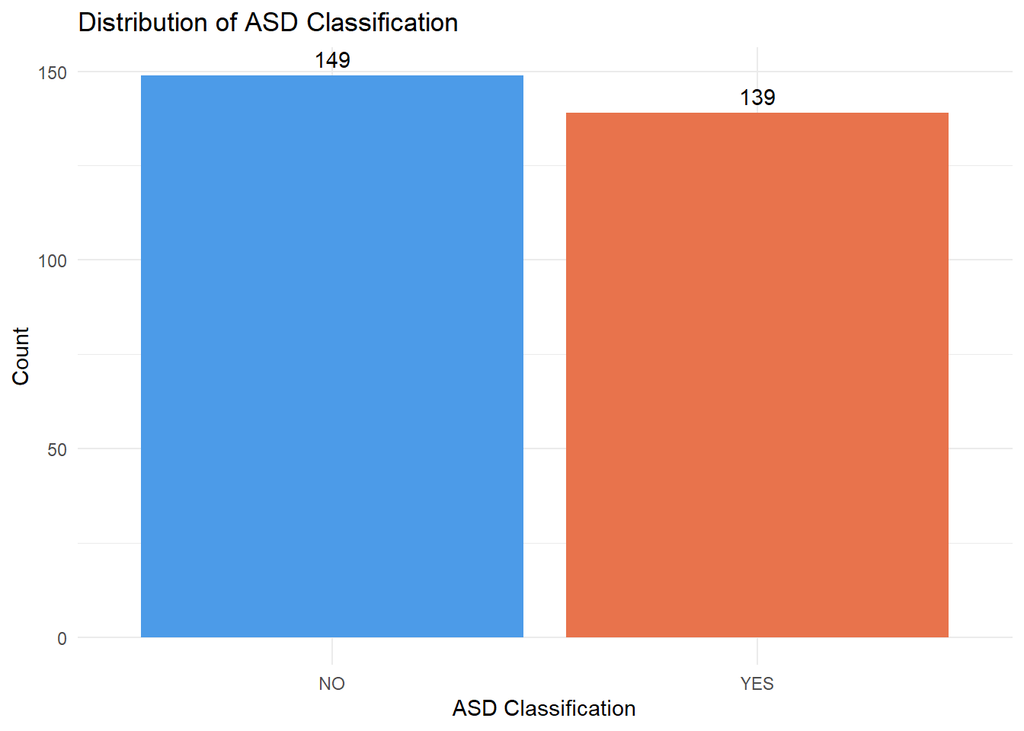

The dataset contains 149 children classified as non-ASD (NO) and 139 classified as ASD (YES), representing a near-equal 52/48 split. This balance is unusual for clinical screening data and likely reflects deliberate curation for research purposes rather than real-world prevalence rates.

## 2. Screening Score by ASD Classification

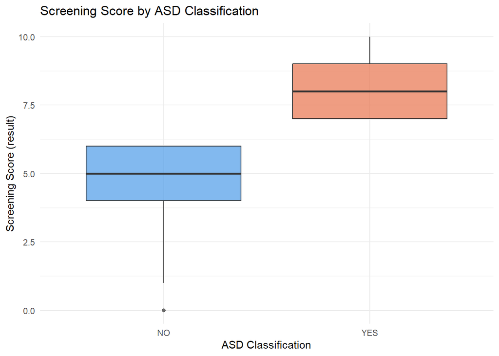

Children classified with ASD show consistently higher screening scores, with a median of approximately 8, compared to a median of around 5 for non-ASD children. The ASD group also shows much less variability, suggesting that a threshold score of around 7 may be a strong indicator of ASD classification in this dataset.

## 3. Demographic Patterns

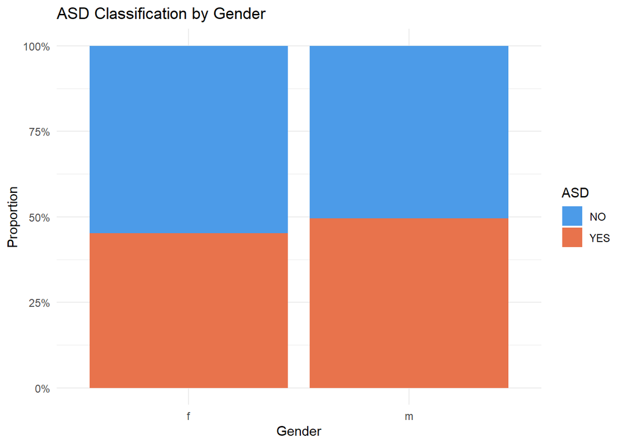

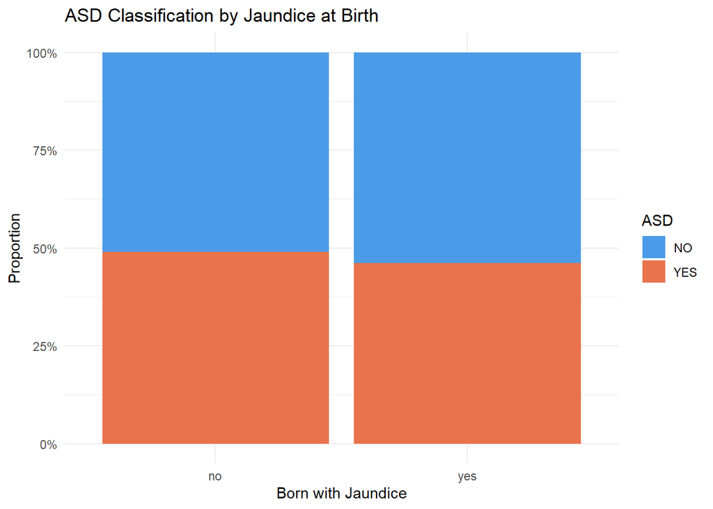

Gender shows no meaningful difference in ASD classification rates, with both males and females showing an approximately equal split between YES and NO outcomes. Similarly, jaundice at birth does not appear to be a strong differentiator, with children born with and without jaundice showing comparable ASD classification proportions.

## 4. AQ-10 Question Scores

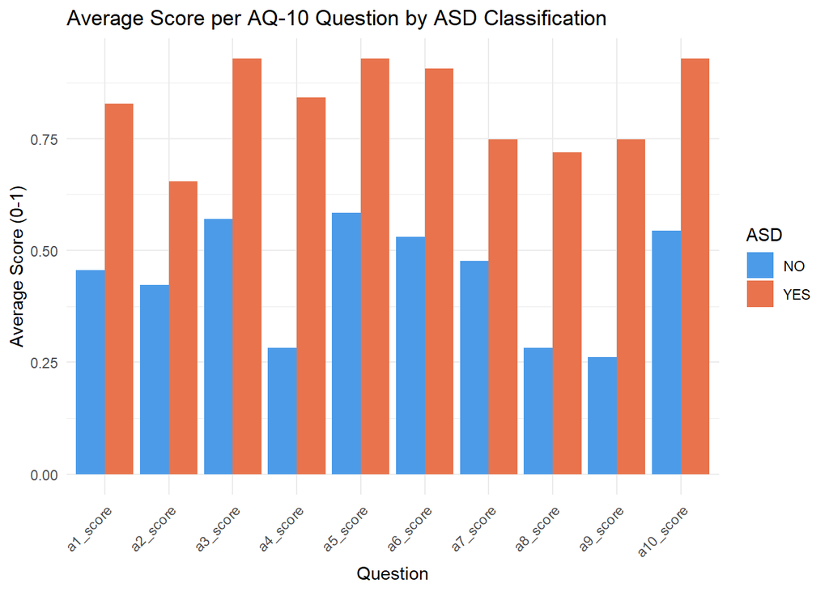

Across almost all ten AQ-10 questions, children classified with ASD scored 1 at a higher average rate than non-ASD children. Questions A4, A8, A9, and A10 show the largest gaps between the two groups, suggesting these items are the most discriminating between ASD and non-ASD children.

# Summary

This exploratory analysis of the ASD screening dataset reveals several clear patterns. Screening scores are strongly separated between ASD and non-ASD groups, with ASD-classified children scoring consistently higher and within a tighter range. Demographic variables such as gender and jaundice history show little association with ASD classification in this dataset. At the question level, items A4, A8, A9, and A10 appear to be the most useful discriminators between the two groups. Overall, the AQ-10-Child screening tool shows strong potential as a classification aid, with screening score alone appearing to be a reliable indicator of ASD outcome in this sample.

# Dataset Limitations

Several limitations should be considered when interpreting these findings. First, the dataset contains only 288 records after cleaning, which is a relatively small sample for drawing broad conclusions about ASD screening patterns across populations. Second, the near-equal split between ASD and non-ASD cases (52/48) is unlikely to reflect real-world prevalence, where ASD affects an estimated 1-2% of the general population, suggesting the dataset was deliberately balanced for research and classification purposes. Third, the dataset draws heavily from certain countries and ethnic groups, limiting how generalisable the findings are to a global population. Finally, this analysis is exploratory in nature — the patterns identified here describe associations in the data and should not be interpreted as clinical diagnostic criteria.